# Cross-recurrence quantification analysis of caregiver-child number talk

By: Shirley Duong (shd77@pitt.edu, shirleyduong5@gmail.com)

Last updated: 04/13/24

This document reports on an application of categorical cross-recurrence quantification analysis (CRQA) to number- and math-related conversations (i.e., number talk) between parents and their preschool-aged children using the [‘crqa’ package](https://cran.r-project.org/web/packages/crqa/crqa.pdf) ([Coco et al., 2021](https://journal.r-project.org/archive/2021/RJ-2021-062/RJ-2021-062.pdf)). Additionally, relations between the CRQA-derived measures and children’s math, language, and executive functioning skills were examined.

This analysis is presented in the article, [“Dynamic structures of parent-child number talk: An application of categorical cross-recurrence quantification analysis and companion to Duong et al. (2024).”](https://www.tqmp.org/RegularArticles/vol20-2/p137/p137.pdf)

**General steps**:

- Describe the sample of parent-child dyads.
- Set up and run CRQA on parent-child number talk.
- Extract CRQA measures, e.g., percent recurrence.
- Generate recurrence plots of several examples.
- Impute child assessment data.
- Model relations between CRQA-derived measures and child outcomes.

First, import the necessary libraries to carry out the steps above.

```r
# data manipulation
library(tidyverse)
library(reshape) # for melting data to generate recurrence plots

# descriptives
library(psych)

# correlations
library(Hmisc) # for correlation function

# plotting and displays
library(ggplot2)
library(knitr)
library(gridExtra)

# recurrence analysis
library(crqa)

# missing data
library(visdat) # for visualizing missingness
library(mice) # for imputation
library(miceadds) # for pooling functions
```

Import event series data (`d`) and parent demographics and child outcomes data (`o`).

```r
d <- read.csv("Number_Talk_Event_Series.csv")
o <- read.csv("Parent_Child_Outcomes.csv")
```

# 1 Sample description

## 1.1 Demographics

Parents in this sample were mostly mothers.

```r
o %>%
  count(relation_to_child) %>%
  mutate(prop = n/sum(n))
```

```
##   relation_to_child   n       prop
## 1            Father   6 0.04838710
## 2            Mother 109 0.87903226
## 3              <NA>   9 0.07258065
```

Parents in this sample were mostly White and non-Hispanic, followed by Black, Asian, and multiracial or another reported race or ethnicity.

```r
o %>%
  count(parent_race_ethnicity) %>%
  mutate(prop = n/sum(n))
```

```
##   parent_race_ethnicity  n       prop
## 1                 Asian  5 0.04032258
## 2                 Black 14 0.11290323
## 3       Hispanic/Latino  2 0.01612903
## 4     Other/Multiracial  5 0.04032258
## 5    White Non-Hispanic 98 0.79032258
```

Most parents in this sample had at least a Bachelors degree.

```r
o %>%
  count(parent_education_category) %>%
  mutate(prop = n/sum(n))
```

```
##     parent_education_category  n        prop
## 1            Associate Degree  6 0.048387097
## 2            Bachelors Degree 22 0.177419355
## 3                      HS/GED  4 0.032258065
## 4         Nursing certificate  1 0.008064516
## 5 Some college, but no degree 10 0.080645161
## 6          Some graduate work 70 0.564516129
## 7                        none  2 0.016129032
## 8                        <NA>  9 0.072580645
```

On average, parents in this sample completed 16 years of schooling. Families’ yearly household income ranged from 5,000 to 350,000 USD and children were 4.40 years old on average.

```r
o %>% dplyr::select(parent_education_years, family_yearly_income, child_age) %>%
  psych::describe() %>% as.data.frame() %>%
  dplyr::select(n, mean, sd, median, min, max, skew, kurtosis, se)
```

```
##                          n         mean           sd      median  min
## parent_education_years 124 1.611290e+01 2.145935e+00    16.00000   11
## family_yearly_income   122 1.061967e+05 6.911448e+04 98500.00000 5000
## child_age              124 4.396988e+00 2.996973e-01     4.32035    4
##                               max       skew   kurtosis           se
## parent_education_years 1.8000e+01 -0.8405795 -0.5700245 1.927106e-01
## family_yearly_income   3.5000e+05  1.1933065  1.5693298 6.257331e+03
## child_age              4.9829e+00  0.3393032 -1.2305393 2.691361e-02
```

## 1.2 Talk and child outcomes

Parent and child (number) utterances and children’s math, language, and executive functioning skills varied considerably.

```r
out <- o %>%
  dplyr::select(total_parent_utterances, total_child_utterances,
                parent_number_utterances, child_number_utterances,
                child_math, child_vocabulary,
                child_executive_function, child_age)

out <- psych::describe(out) %>%
  as.data.frame() %>%
  dplyr::select(n, mean, sd, median, min, max, skew, kurtosis, se)

# make table pretty
colnames(out) = c("n", "Mean", "SD", "median", "Min", "Max", "Skew", "Kurtosis", "SE")
row.names(out) = c("Total parent utterances", "Total child utterances",
"Parent number utterances", "Child number utterances",
"Child math", "Child vocabulary", "Child executive function", "Child age")

# show table
kable(out, digits=2)
```

|  | n | Mean | SD | median | Min | Max | Skew | Kurtosis | SE |
| --- | --- | --- | --- | --- | --- | --- | --- | --- | --- |
| Total parent utterances | 124 | 155.14 | 49.53 | 150.00 | 7 | 408.00 | 1.59 | 6.70 | 4.45 |
| Total child utterances | 124 | 101.99 | 36.23 | 100.50 | 12 | 241.00 | 0.43 | 0.70 | 3.25 |
| Parent number utterances | 124 | 21.20 | 14.43 | 18.00 | 0 | 67.00 | 1.09 | 0.94 | 1.30 |
| Child number utterances | 124 | 13.55 | 11.59 | 10.00 | 0 | 78.00 | 2.18 | 7.21 | 1.04 |
| Child math | 118 | 115.14 | 12.41 | 116.50 | 70 | 147.00 | -0.61 | 1.79 | 1.14 |
| Child vocabulary | 111 | 105.58 | 29.91 | 106.00 | 11 | 179.00 | -0.05 | 0.37 | 2.84 |
| Child executive function | 119 | 14.71 | 5.71 | 18.00 | 5 | 24.00 | -0.62 | -1.17 | 0.52 |
| Child age | 124 | 4.40 | 0.30 | 4.32 | 4 | 4.98 | 0.34 | -1.23 | 0.03 |

# 2 Set-up CRQA

Event series variables (in `d`):

- `preID`: Dyad identifier
- `timepoint`: The order in which the parent or child utterance appeared in the conversation; takes on values of 1 to the total number of utterances spoken in each interaction
- `source`: Speaker, **p** = *parent*, **c** = *child*
- `parent_ts`: Event series of parent utterances, coded as **1** = *engaging in number talk*, **2** = *non-number talk*, **3** = *parent non-number talk*, or **5** = *no utterance from the parent during non-NT of the child*
- `child_ts`: Event series of child utterances, coded as **1** = *engaging in number talk*, **2** = *non-number talk*, **4** = *child non-number talk*, or **6** = *no utterance from the child during non-NT of the parent*

```r
d %>% glimpse()
```

```
## Rows: 31,854
## Columns: 5
## $ preID     <int> 1, 1, 1, 1, 1, 1, 1, 1, 1, 1, 1, 1, 1, 1, 1, 1, 1, 1, 1, 1, …
## $ source    <chr> "p", "c", "p", "c", "p", "c", "p", "p", "p", "p", "c", "p", …
## $ timepoint <int> 1, 2, 3, 4, 5, 6, 7, 8, 9, 10, 11, 12, 13, 14, 15, 16, 17, 1…
## $ parent_ts <int> 3, 5, 3, 5, 3, 5, 3, 3, 3, 1, 5, 3, 3, 5, 3, 3, 3, 5, 3, 5, …
## $ child_ts  <int> 6, 4, 6, 4, 6, 4, 6, 6, 6, 2, 4, 6, 6, 4, 6, 6, 6, 4, 6, 4, …
```

Specify CRQA hyperparameters. For this analysis, we used a radius (`radius` argument in `crqa()`) of .5, a delay (`delay`) of 0, and an embedded dimension (`embed`) of 1.

```r
radius_value = .5
delay_value = 0
embedding_value = 1
```

# 3 Run CRQA

Use the `crqa()` function from the ‘crqa’ package to run the recurrence analysis.

## 3.1 Example data

Run CRQA on a segment of one parent-child conversation to show the process and output. The output contains the values of 10 recurrence measures (e.g., `$RR`) and 1 matrix that visually indicates recurrent points with lines (`$RP`).

```r
# parent and child event series
example_parent_ts <- c(3, 2, 1, 1, 2, 1, 3, 5, 1, 2, 1, 1, 5, 1, 1)
example_child_ts <- c(6, 1, 2, 2, 1, 2, 6, 4, 2, 1, 2, 2, 4, 2, 2)

# run crqa
example_analysis <- crqa(example_parent_ts,
                         example_child_ts,
                         radius = radius_value,
                         delay = delay_value,
                         embed = embedding_value,

                         # below are default arguments
                         rescale = 0, # do *not* rescale
                         normalize = 0, # do *not* normalize
                         mindiagline = 2, # minimum diagonal length of recurrent points
                         minvertline = 2 # minimum vertical length of recurrent points
                         )

# show output
example_analysis
```

```
## $RR
## [1] 21.33333
##
## $DET
## [1] 50
##
## $NRLINE
## [1] 12
##
## $maxL
## [1] 2
##
## $L
## [1] 2
##
## $ENTR
## [1] 0
##
## $rENTR
## [1] NaN
##
## $LAM
## [1] 37.5
##
## $TT
## [1] 2
##
## $catH
## [1] NA
##
## $RP
## 15 x 15 sparse Matrix of class "ngCMatrix"
##
##  [1,] . . . . . . . . . . . . . . .
##  [2,] . . | | . | . . | . | | . | |
##  [3,] . | . . | . . . . | . . . . .
##  [4,] . | . . | . . . . | . . . . .
##  [5,] . . | | . | . . | . | | . | |
##  [6,] . | . . | . . . . | . . . . .
##  [7,] . . . . . . . . . . . . . . .
##  [8,] . . . . . . . . . . . . . . .
##  [9,] . | . . | . . . . | . . . . .
## [10,] . . | | . | . . | . | | . | |
## [11,] . | . . | . . . . | . . . . .
## [12,] . | . . | . . . . | . . . . .
## [13,] . . . . . . . . . . . . . . .
## [14,] . | . . | . . . . | . . . . .
## [15,] . | . . | . . . . | . . . . .
```

## 3.2 Descriptive analysis data

Apply `crqa()` to the case study data for each parent-child dyad using `group_by()`. Extract the **recurrence rate** (`RR`), **percent determinism** (`DET`), **mean diagonal line** (`meanL`), **laminarity** (`LAM`), and **trapping time** (`TT`) by accessing those attributes of the CRQA output with `$`. Assign to a new dataframe where each row corresponds to one parent-child dyad.

```r
d_crqa <- d %>%
  group_by(preID) %>%
  summarise(RR = crqa(parent_ts, child_ts,
                      radius = radius_value,
                      delay = delay_value,
                      embed = embedding_value)$RR,
            DET = crqa(parent_ts, child_ts,
                       radius = radius_value,
                       delay = delay_value,
                       embed = embedding_value)$DET,
            meanL = crqa(parent_ts, child_ts,
                         radius = radius_value,
                         delay = delay_value,
                         embed = embedding_value)$L,
            LAM = crqa(parent_ts, child_ts,
                       radius = radius_value,
                       delay = delay_value,
                       embed = embedding_value)$LAM,
            TT = crqa(parent_ts, child_ts,
                      radius = radius_value,
                      delay = delay_value,
                      embed = embedding_value)$TT
            )

# change all NAs to 0s
d_crqa[is.na(d_crqa)] <- 0

# glimpse at the new dataframe
d_crqa %>% glimpse()
```

```
## Rows: 124
## Columns: 6
## $ preID <int> 1, 2, 3, 4, 5, 6, 7, 8, 9, 10, 11, 12, 13, 14, 15, 16, 17, 18, 1…
## $ RR    <dbl> 1.38651731, 0.47001015, 1.53535354, 4.17473277, 0.09660669, 2.44…
## $ DET   <dbl> 26.108374, 17.424242, 30.622010, 18.447581, 0.000000, 34.032984,…
## $ meanL <dbl> 2.000000, 2.090909, 2.909091, 2.204819, 0.000000, 2.316327, 2.14…
## $ LAM   <dbl> 22.660099, 39.772727, 52.870813, 25.453629, 0.000000, 48.688156,…
## $ TT    <dbl> 2.164706, 2.234043, 5.390244, 2.285068, 0.000000, 2.418994, 2.23…
```

# 4 Descriptives

CRQA measures of interest:

- **Recurrence rate** (`RR`): Percentage of recurrent points in a RP. How often is number talk co-occurring or being reciprocated?
- **Determinism** (`DET`): Percentage of recurrent points that form diagonal lines. How often do parents and children follow each others’s number utterances or engage in “back and forth” number exchanges?
- **Average diagonal line** (`meanL`) - Mean length of diagonal lines or number exchanges.
- **Laminarity** (`LAM`) – Percentage of recurrent points that form vertical (or horizontal) lines. How often does one speaker use consecutive number utterances after the other person introduces or uses number talk?
- **Trapping time** (`TT`) - Average length of vertical lines.

Obtain descriptive statistics of the CRQA measures using the `describe()` function from the ‘psych’ package.

```r
crqa_summary <- d_crqa %>%
  dplyr::select(-preID) %>%
  psych::describe() %>%
  as.data.frame() %>%
  dplyr::select(n, mean, sd, median, min, max, skew, kurtosis, se)

# make table pretty
colnames(crqa_summary) = c("n", "Mean", "SD", "median", "Min", "Max", "Skew", "Kurtosis", "SE")

row.names(crqa_summary) = c("Recurrence rate", "Determinism", "Mean diagonal line", "Laminarity", "Trapping time")

# show table
kable(crqa_summary, digits = 2)
```

|  | n | Mean | SD | median | Min | Max | Skew | Kurtosis | SE |
| --- | --- | --- | --- | --- | --- | --- | --- | --- | --- |
| Recurrence rate | 124 | 1.09 | 1.32 | 0.67 | 0 | 7.33 | 2.17 | 5.49 | 0.12 |
| Determinism | 124 | 16.17 | 12.46 | 15.97 | 0 | 54.71 | 0.47 | -0.35 | 1.12 |
| Mean diagonal line | 124 | 1.77 | 0.81 | 2.00 | 0 | 3.00 | -1.59 | 0.86 | 0.07 |
| Laminarity | 124 | 21.52 | 16.34 | 22.69 | 0 | 63.69 | 0.24 | -0.80 | 1.47 |
| Trapping time | 124 | 1.91 | 1.18 | 2.11 | 0 | 5.39 | -0.33 | -0.07 | 0.11 |

Visualize the distributions of the measures.

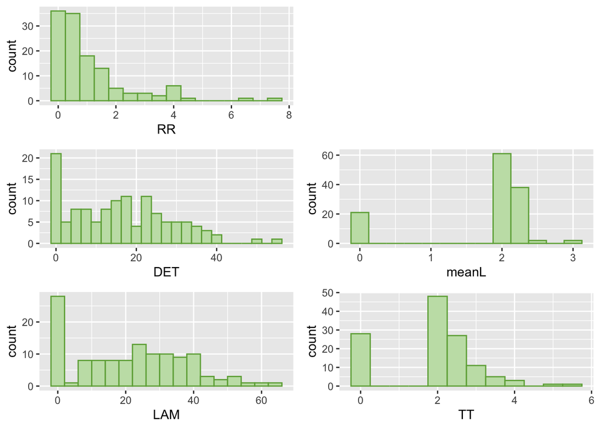

```r
# plot histograms in a grid
grid.arrange(

  # recurrence rate
  d_crqa %>% ggplot(mapping = aes(x = RR)) +
  geom_histogram(binwidth = .5,
                 color = "#6FAC47", fill = "#C5E0B4"),

  # determinism
  d_crqa %>% ggplot(mapping = aes(x = DET)) +
  geom_histogram(binwidth = 2.5,
                 color = "#6FAC47", fill = "#C5E0B4"),

  # mean diagonal line
  d_crqa %>% ggplot(mapping = aes(x = meanL)) +
  geom_histogram(binwidth = .25,
                 color = "#6FAC47", fill = "#C5E0B4"),

  # laminarity
  d_crqa %>% ggplot(mapping = aes(x = LAM)) +
  geom_histogram(binwidth = 4,
                 color = "#6FAC47", fill = "#C5E0B4"),

  # trapping time
  d_crqa %>% ggplot(mapping = aes(x = TT)) +
  geom_histogram(binwidth = .5,
                 color = "#6FAC47", fill = "#C5E0B4"),

  # grid arrangement
  layout_matrix = rbind(c(1, NA), # NA specifies that no plot should be in that location
                        c(2,3),
                        c(4,5))
)
```

Note that `meanL` and `TT` cannot take one values of 1; the minimum length of diagonal and vertical lines is 2.

# 5 Recurrence plots

Generate recurrence plots (RPs) for **six** example conversations: one with a relatively high RR, one with RR = 0 (but includes parent number talk), and four with relatively similar frequencies of parent number utterances but differing RR, DET, and/or LAM.

**Reading the plots**:

- The parent event series is plotted along the x-axis and the child event series is plotted along the y-axis.
- The blue (parent) and red (child) rug marks (thin lines) along the axes represent whether a number utterance occurred at a particular point in time. This can be summarized to show the *frequency* of number talk.
- The purple areas on the plot represent when number talk co-occurred. This can be summarized to show the *reciprocity* of number talk.
- The black diagonal line is the line of incidence, which reflects when talk occurs at the same moment in time. In our case of conversational exchanges, recurrence along this line is not present, so this appears on the plot just for reference.

## 5.1 Example data

Generate the RP of the example data to show the process and output.

First, extract the RP from the example and reshape the data so that there are 3 columns: the parent event series, the child event series, and `value` which indicates whether each pair of parent-child utterances is a recurrent point. Also, the number of rows should equal the square of the length of the event series. In this case, it’s 15 squared or 225.

```r
# extract RP from the crqa output
recurrence_matrix <- melt(as.matrix(example_analysis$RP),
                          varnames = c("example_child_ts", "example_parent_ts"))

recurrence_matrix %>% glimpse()
```

```
## Rows: 225
## Columns: 3
## $ example_child_ts  <int> 1, 2, 3, 4, 5, 6, 7, 8, 9, 10, 11, 12, 13, 14, 15, 1…
## $ example_parent_ts <int> 1, 1, 1, 1, 1, 1, 1, 1, 1, 1, 1, 1, 1, 1, 1, 2, 2, 2…
## $ value             <lgl> FALSE, FALSE, FALSE, FALSE, FALSE, FALSE, FALSE, FAL…
```

Then, use ggplot’s `geom_raster()` to generate the RP (showing the *recurrence* of number talk).

```r
recurrence_plot <- recurrence_matrix %>%
  ggplot(mapping = aes(x = example_parent_ts,
                       y = example_child_ts,
                       fill = value)
         ) +
  geom_raster() +
  scale_fill_manual(values=c("#a269db", # purple for recurrent points
                             "#F5F5F5"), # gray for non-recurrence points
                    breaks=c(TRUE, FALSE)) +
  geom_abline(intercept = 0, slope = 1) # add line of incidence

# recurrence_plot
```

Generate the data for the rugs (showing the *occurrence* of number talk) and then add to the RP.

```r
# first combine event series into a data frame
plot_data <- cbind(example_parent_ts, example_child_ts) %>%
  as.data.frame() %>%
  rowid_to_column("utterance_order") %>%
  mutate(x_binary = ifelse(example_parent_ts == 1, utterance_order, NA), # NA to ensure no rug mark appears when number talk is *not* being used
         y_binary = ifelse(example_child_ts == 1, utterance_order, NA)
         ) %>%
  # add rug colors for each speaker
  mutate(rug_color = ifelse(!is.na(x_binary) & is.na(y_binary), "red", # child
                            ifelse(!is.na(y_binary) & is.na(x_binary), "blue", NA) # parent
                            )
         )

# add rugs to the axes
recurrence_plot <- recurrence_plot +
  geom_rug(inherit.aes = FALSE, # ensure that the mapping from above does not get combined
           data = plot_data,
           mapping = aes(x = x_binary,
                         y = y_binary,
                         color = rug_color)) +
  scale_color_manual(values=c("#D70040", # red for child
                              "#0096FF")) # blue for parent

# recurrence_plot
```

Adjust the RP aesthetics and display the plot.

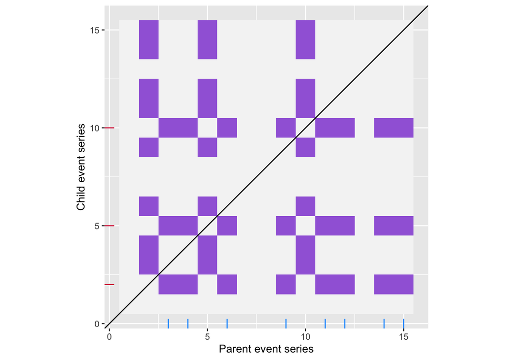

```r
recurrence_plot <- recurrence_plot +
  # adjust RP aesthetics
  theme(axis.line = element_blank(), # remove axis lines/tick marks
        legend.position = "none") +  # remove legend
  coord_equal() + # make square
  labs(x = "Parent event series", y = "Child event series") # add axis labels

# show plot
recurrence_plot
```

## 5.2 Generate RP function

Write a function with the code above to create RPs.

```r
make_recurrence_plot <- function(data, chosen_dyad){

  # subset data
  d_use <- data %>% filter(preID == chosen_dyad)

  # run crqa
  crqa_output <- crqa(d_use$parent_ts,
                      d_use$child_ts,
                      radius = radius_value,
                      delay = delay_value,
                      embed = embedding_value)

  # extract recurrence plot from crqa output
  if(class(crqa_output$RP) == "logical"){ # if RR = 0...

    # the crqa() function does not supply an RP if there is no recurrence
    # in these cases, the class of $RP is "logical", not a matrix
    # so we need to supply a matrix for these cases
    # the matrix needs to have the same dimensions as the total number of utterances in the conversation

    child_ts_zeroRR <- c(1:nrow(d_use))
    parent_ts_zero_RR <- c(1:nrow(d_use))

    # generate all possible combinations of time points
    recurrence_matrix <- expand.grid(child_ts_zeroRR, parent_ts_zero_RR) %>%
      as.data.frame() %>%
      mutate(value = FALSE) %>% # specify no recurrence at all pairs of time points
      dplyr::rename(child_ts = Var1,
                    parent_ts = Var2)

  } else {
    # else use the RP provided by crqa() and reshape data
    recurrence_matrix <- melt(as.matrix(crqa_output$RP),
                          varnames = c("child_ts", "parent_ts"))

  }


  # generate rp using geom_raster()
  recurrence_plot <- recurrence_matrix %>%
  ggplot(mapping = aes(x = parent_ts,
                       y = child_ts,
                       fill = value)
         ) +
  geom_raster() +
  scale_fill_manual(values=c("#a269db", # purple for recurrent points
                             "#F5F5F5"), # gray for non-recurrence points
                    breaks=c(TRUE, FALSE)) +
  geom_abline(intercept = 0, slope = 1) # add line of incidence

  # add rugs
  plot_data <- cbind(d_use$parent_ts, d_use$child_ts) %>%
  as.data.frame() %>%
  rowid_to_column("utterance_order") %>%
  mutate(x_binary = ifelse(V1 == 1, utterance_order, NA), # NA to ensure no rug mark appears when number talk is *not* being used
         y_binary = ifelse(V2 == 1, utterance_order, NA)
         ) %>%
  # add rug colors for each speaker
  mutate(rug_color = ifelse(!is.na(x_binary) & is.na(y_binary), "red", # child
                            ifelse(!is.na(y_binary) & is.na(x_binary), "blue", # parent
                                   NA)
                            )
         )

  recurrence_plot <- recurrence_plot +
    geom_rug(inherit.aes = FALSE, # ensure that the mapping from above does not get combined
             data = plot_data,
             mapping = aes(x = as.numeric(x_binary),
                           y = as.numeric(y_binary),
                           color = as.character(rug_color))) +
    scale_color_manual(values=c("#D70040", # red for child
                                "#0096FF")) # blue for parent

  # adjust rp aesthetics
  recurrence_plot <- recurrence_plot +
  # adjust RP aesthetics
    theme(axis.line = element_blank(), # remove axis lines/tick marks
        legend.position = "none") +  # remove legend
    coord_equal() + # make square
    labs(x = "Parent event series (Time point)", y = "Child event series (Time point)") # add axis labels

  # show plot
  recurrence_plot
}
```

## 5.3 Descriptive analysis data

### 5.3.1 Summary statistics

Display the values of the CRQA-derived measures and frequencies of (number) talk for the example dyads.

```r
# list of dyad IDs
example_dyad_IDs <- c(46, 63, 89, 53, 55, 116)

# obtain relevant data
example_dyads <- merge(

  # frequencies of talk
  o %>% filter(preID %in% example_dyad_IDs) %>%
    dplyr::select(preID, total_parent_utterances, total_child_utterances,
                  parent_number_utterances, child_number_utterances),

  # crqa measures
  d_crqa %>% filter(preID %in% example_dyad_IDs) %>%
    dplyr::select(preID, RR, DET, meanL, LAM, TT),

  # key
  by = "preID"

)

# transpose table
example_dyads <- t(example_dyads)

# reorder cols so dyads appear in the same order as article
example_dyads <- example_dyads %>%
  as.data.frame() %>%
  dplyr::select(V1, V4, V5, V2, V3, V6)

# remove `preID` row and rename cols and rows
example_dyads <- example_dyads[-1,]

colnames(example_dyads) = c("1", "2", "3", "4", "5", "6")

row.names(example_dyads) = c("Total parent utterances", "Total child utterances",
                             "Parent number utterances", "Child number utterances",
                             "Recurrence rate (%)", "Determinism (%)",
                             "Mean diagonal line",
                             "Laminarity (%)", "Trapping time"
                             )

# show table
kable(example_dyads, digits=2)
```

|  | 1 | 2 | 3 | 4 | 5 | 6 |
| --- | --- | --- | --- | --- | --- | --- |
| Total parent utterances | 134.00 | 112 | 160.00 | 144.00 | 164.00 | 89.00 |
| Total child utterances | 56.00 | 112 | 106.00 | 108.00 | 115.00 | 75.00 |
| Parent number utterances | 50.00 | 6 | 23.00 | 21.00 | 25.00 | 17.00 |
| Child number utterances | 27.00 | 0 | 6.00 | 16.00 | 17.00 | 10.00 |
| Recurrence rate (%) | 7.33 | 0 | 0.28 | 1.06 | 1.09 | 1.26 |
| Determinism (%) | 33.18 | 0 | 1.45 | 35.71 | 5.18 | 54.71 |
| Mean diagonal line | 2.39 | 0 | 2.00 | 3.00 | 2.00 | 2.11 |
| Laminarity (%) | 38.47 | 0 | 26.09 | 63.69 | 17.88 | 23.53 |
| Trapping time | 2.44 | 0 | 3.00 | 4.76 | 2.00 | 2.00 |

### 5.3.2 Example dyad 1

**High number talk (NT) frequencies, high RR**

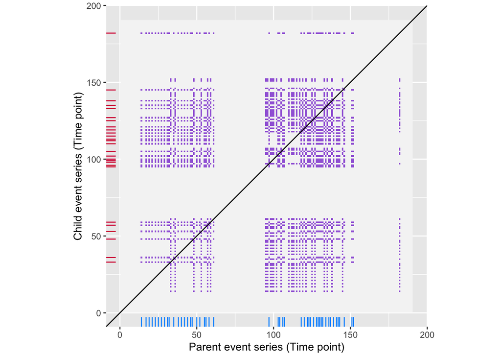

```r
make_recurrence_plot(d, 46)
```

### 5.3.3 Example dyad 2

**Low NT frequencies, zero RR**

Only one person used number talk in this conversation. This was the case for **5** dyads in the sample. Total parent utterances = 112, total child utterances = 112, parent NT = 6, child NT = 0.

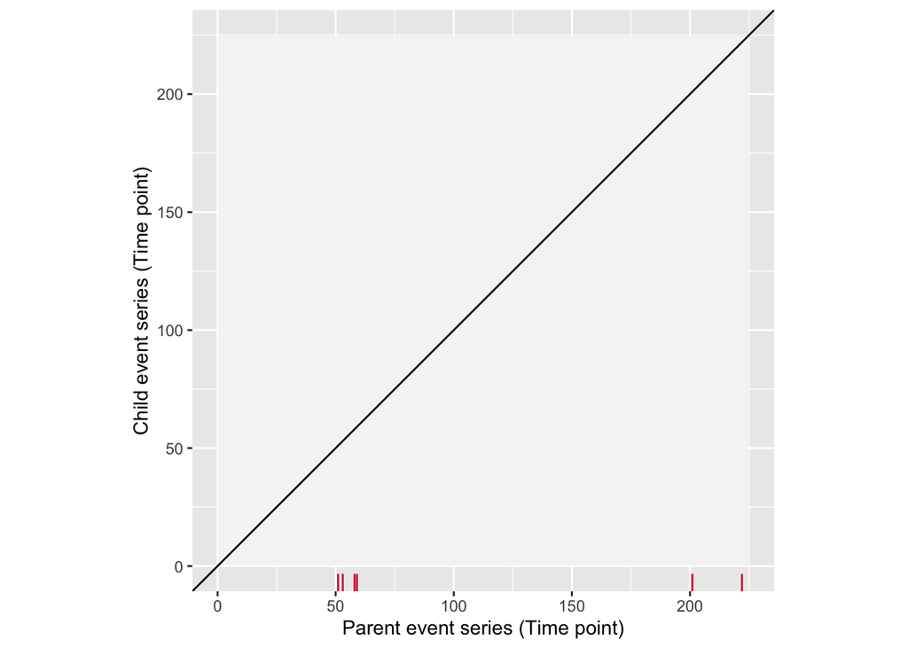

```r
make_recurrence_plot(d, 63)
```

### 5.3.4 Example dyad 3

**Average NT frequencies, low RR**

Total parent utterances = 160, total child utterances = 106, parent NT = 23, child NT = 6, RR = .28, DET = 1.45, meanL = 2, LAM = 26.09, TT = 3.

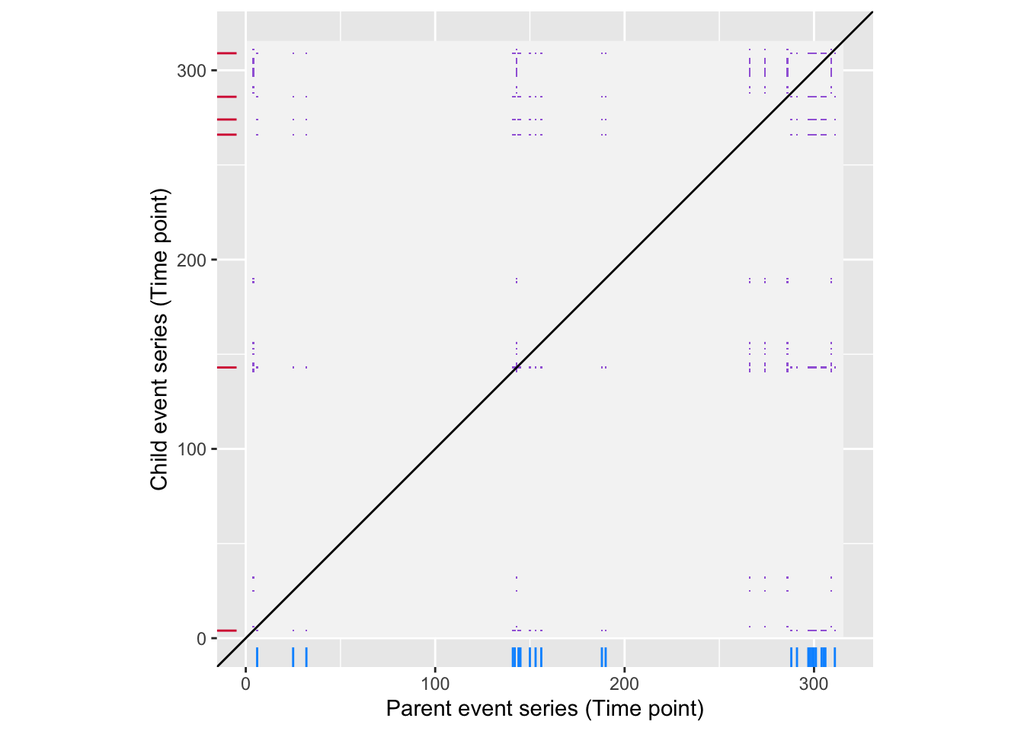

```r
make_recurrence_plot(d, 89)
```

### 5.3.5 Example dyad 4

**Average NT, average RR, high LAM**

Total parent utterances = 144, total child utterances = 108, parent NT = 21, child NT = 16, RR = 1.06, DET = 35.71, meanL = 3, LAM = 63.69, TT = 4.76.

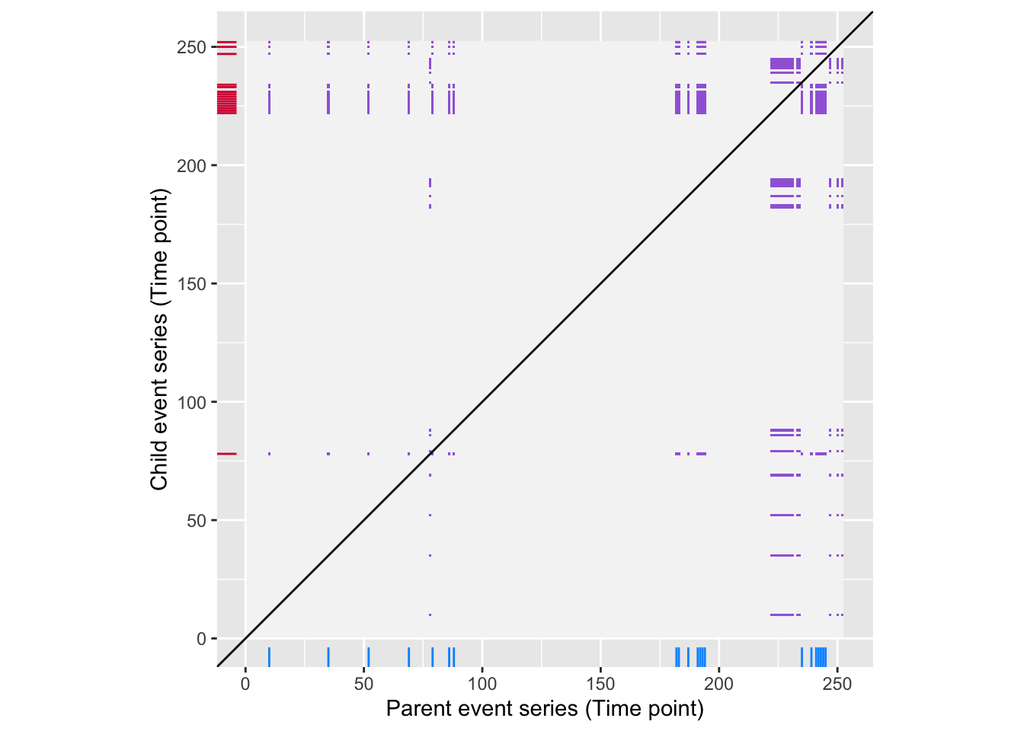

```r
make_recurrence_plot(d, 53)
```

### 5.3.6 Example dyad 5

**Average NT, average RR, low DET**

Total parent utterances = 164, total child utterances = 115, parent NT = 25, child NT = 17, RR = 1.09, DET = 5.18, meanL = 2, LAM = 17.88, TT = 2.

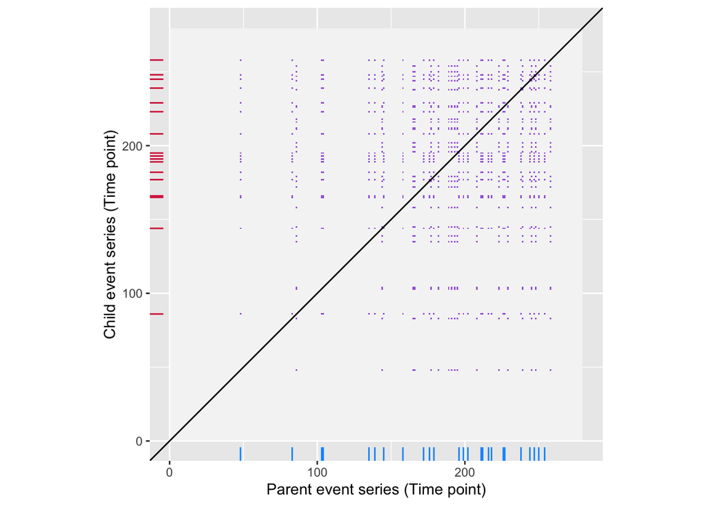

```r
make_recurrence_plot(d, 55)
```

### 5.3.7 Example dyad 6

**Average NT, average RR, high DET**

Total parent utterances = 89, total child utterances = 75, parent NT = 17, child NT = 10, RR = 1.26, DET = 54.71, meanL = 2.11, LAM = 23.53, TT = 2.

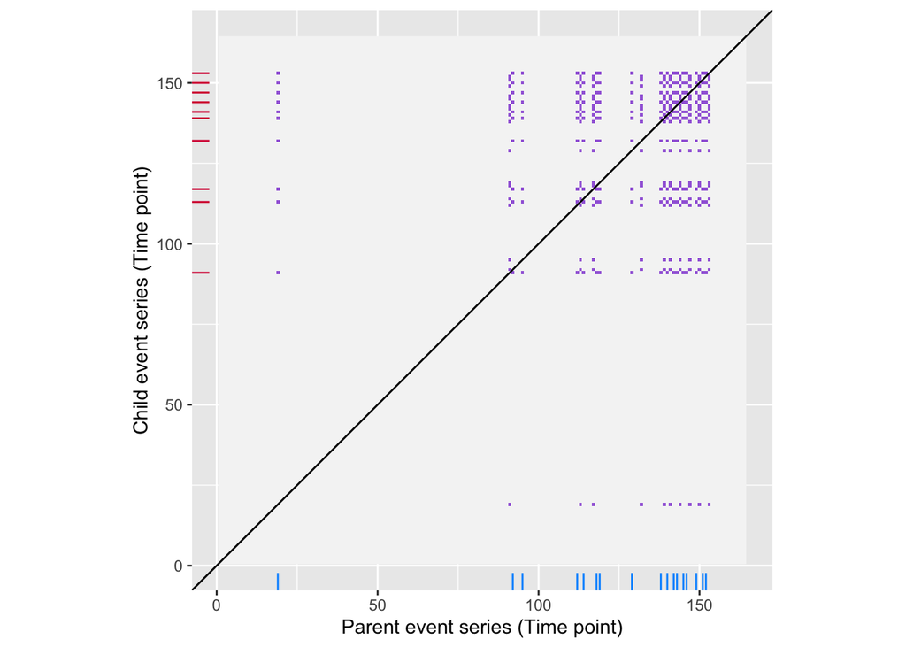

```r
make_recurrence_plot(d, 116)
```

# 6 Inferential statistics

```r
all_data <- merge(d_crqa, o, by = "preID", all = TRUE)
```

## 6.1 Missing data imputation

Visualize patterns of missing data.

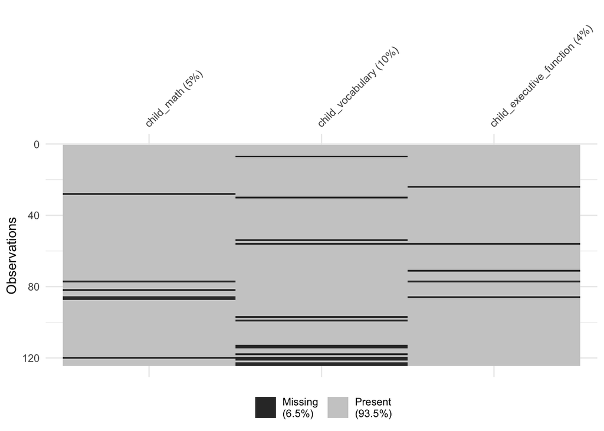

```r
vis_miss(all_data %>%
           dplyr::select(child_math, child_vocabulary, child_executive_function))
```

Perform missing data imputation using `mice()` from the ‘mice’ package. Several complete datasets will be created that draw from the distribution of the existing data. First, set the predictor matrix, which indicates which variables are going to be used to predict the values of the missing data.

```r
# make copy of dataset
all_data_use <- all_data

# first, run with 0 iterations
imp <- mice(all_data_use, maxit=0)
# extract the predictor matrix and methods of imputation
predM = imp$predictorMatrix
meth = imp$method

# set predictor matrix
# 0 = variable is *not* used to predict missing values
predM[, c("preID")] = 0
predM[, c("RR")] = 0
predM[, c("DET")] = 0
predM[, c("meanL")] = 0
predM[, c("LAM")] = 0
predM[, c("TT")] = 0
```

```r
imp_data <- mice(all_data_use,
                 m = 40, # iterations
                 method = c("sample"),
                 seed = 123,
                 print = FALSE)
# summary(imp_data)

# to view the imputed values, use head()
# head(imp_data$imp$child_math)
# head(imp_data$imp$child_vocabulary)
# head(imp_data$imp$child_executive_function)

# create separate data frame for each imputed data set
imp_data1 <- complete(imp_data, 1)
imp_data2 <- complete(imp_data, 2)
imp_data3 <- complete(imp_data, 3)
imp_data4 <- complete(imp_data, 4)
imp_data5 <- complete(imp_data, 5)

#create list of imputed datasets
imp_all <- miceadds::mids2datlist(imp_data)
```

## 6.2 Analytical plan

- Run zero-order correlations between all language input variables.
- Then, estimate stepwise linear regressions predicting child outcomes. In the first step, use total parent and child number talk and child age as predictors (**Models 1**). In the second step, add the percentage recurrence measures, i.e., RR, DET, and LAM (**Models 2**).

## 6.3 Zero-order correlations

```r
set.seed(123)

# correlations with prob of group membership
corr_vars <- colnames(all_data %>% dplyr::select(
  RR:child_age
  )
)

set.seed(123)

corrs <- miceadds::micombine.cor(mi.res = imp_data,
                                 variables = corr_vars)


# reorder values
corrs$variable1 <- factor(corrs$variable1,
                          levels = corr_vars)
corrs$variable2 <- factor(corrs$variable2,
                          levels = corr_vars)


# indicate p-values
corrs <- corrs %>%
  mutate(p_value = ifelse(p < .05 & p >= 0.01, "p < .05",
                          ifelse(p < 0.01 & p >= .001, "p < .01",
                                 ifelse(p < .001 & p >= 0, "p < .001",
                                        "p >= .05")
                                 )
                          )
         )

corrs_p <- corrs %>%
  mutate(r_all = r,
         r = ifelse(p_value == "p >= .05", NA, r_all))
```

Visualize correlations. Colors correspond to the *p*-values corresponding to the associations.

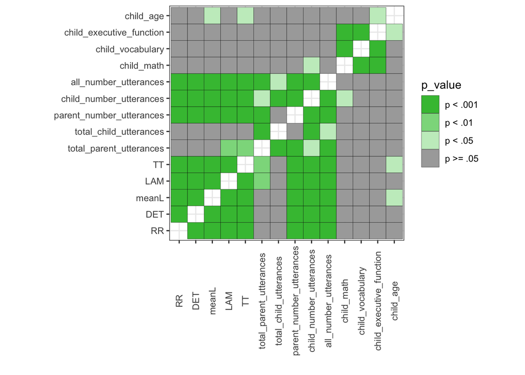

```r
corrs_p %>%
  ggplot(mapping = aes(x = variable1, y = variable2)) +
  geom_tile(mapping = aes(fill = p_value),
            color = "black"
            ) +
  coord_equal() +
  scale_fill_manual(values = c("#40bf40", "#8cd98c", "#c6ecc6", "darkgrey")) +
  labs(x = "", y = "") +
  theme_bw() +
  theme(axis.text.x = element_text(angle = 90, vjust = .5))
```

All coefficients.

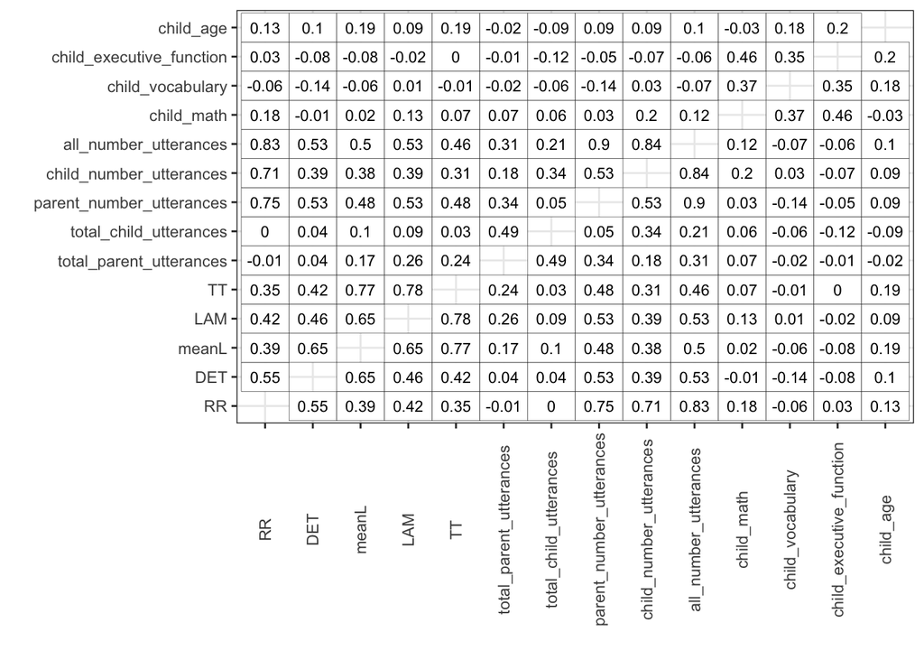

```r
corrs %>%
  ggplot(mapping = aes(x = variable1, y = variable2)) +
  geom_tile(fill = "white",
            color = "black"
            ) +
  geom_text(mapping = aes(label = round(r, 2)),
            size = 3) +
  labs(x = "", y = "") +
  theme_bw() +
  theme(axis.text.x = element_text(angle = 90, vjust = .5))
```

## 6.4 Models 1

In step one, only total number talk and child age used as predictors.

### 6.4.1 Child math

```r
# pooled regression summary
summary(
  pool(
    with(imp_all, lm(scale(child_math) ~  scale(all_number_utterances) + scale(child_age)))
  )
)
```

```
##                           term      estimate  std.error     statistic       df
## 1                  (Intercept)  3.499211e-17 0.08979863  3.896731e-16 119.0365
## 2 scale(all_number_utterances)  1.231972e-01 0.09136301  1.348437e+00 117.0738
## 3             scale(child_age) -3.857780e-02 0.09342031 -4.129488e-01 110.9596
##     p.value
## 1 1.0000000
## 2 0.1801208
## 3 0.6804410
```

```r
# pooled R-squared
pool.r.squared(
  pool(
    with(imp_all, lm(scale(child_math) ~  scale(all_number_utterances) + scale(child_age)))
  )
)
```

```
##            est       lo 95      hi 95        fmi
## R^2 0.01628952 0.002552104 0.08874897 0.00792332
```

### 6.4.2 Child vocabulary

```r
# pooled regression summary
summary(
  pool(
    with(imp_all, lm(scale(child_vocabulary) ~  scale(all_number_utterances) + scale(child_age)))
  )
)
```

```
##                           term      estimate  std.error     statistic       df
## 1                  (Intercept) -5.729314e-17 0.08851442 -6.472747e-16 119.0365
## 2 scale(all_number_utterances) -9.233953e-02 0.09483435 -9.736928e-01 102.1506
## 3             scale(child_age)  1.939868e-01 0.09379852  2.068122e+00 105.4844
##     p.value
## 1 1.0000000
## 2 0.3325092
## 3 0.0410747
```

```r
# pooled R-squared
pool.r.squared(
  pool(
    with(imp_all, lm(scale(child_vocabulary) ~  scale(all_number_utterances) + scale(child_age)))
  )
)
```

```
##           est       lo 95     hi 95       fmi
## R^2 0.0437622 0.000743444 0.1426636 0.0731612
```

### 6.4.3 Child executive function

```r
# pooled regression summary
summary(
  pool(
    with(imp_all, lm(scale(child_executive_function) ~  scale(all_number_utterances) + scale(child_age)))
  )
)
```

```
##                           term      estimate  std.error     statistic       df
## 1                  (Intercept) -3.319241e-17 0.08834880 -3.756973e-16 119.0365
## 2 scale(all_number_utterances) -8.591352e-02 0.08975575 -9.571923e-01 117.4481
## 3             scale(child_age)  2.093209e-01 0.09039254  2.315688e+00 115.6109
##      p.value
## 1 1.00000000
## 2 0.34043638
## 3 0.02233844
```

```r
# pooled R-squared
pool.r.squared(
  pool(
    with(imp_all, lm(scale(child_executive_function) ~  scale(all_number_utterances) + scale(child_age)))
  )
)
```

```
##           est       lo 95     hi 95        fmi
## R^2 0.0477388 0.001785138 0.1455775 0.01789137
```

## 6.5 Models 2

Three of the percentage CRQA measures (i.e., RR, DET, and LAM) were added in step 2.

### 6.5.1 Child math

```r
# pooled regression summary
summary(
  pool(
    with(imp_all, lm(scale(child_math) ~  scale(all_number_utterances) + scale(child_age) + scale(RR) + scale(DET) + scale(LAM)))
  )
)
```

```
##                           term      estimate  std.error     statistic       df
## 1                  (Intercept)  3.341216e-17 0.08861904  3.770314e-16 116.0380
## 2 scale(all_number_utterances) -1.387719e-01 0.17617793 -7.876806e-01 113.1702
## 3             scale(child_age) -5.185764e-02 0.09290498 -5.581793e-01 107.4726
## 4                    scale(RR)  3.356791e-01 0.16822698  1.995394e+00 114.4764
## 5                   scale(DET) -1.774645e-01 0.11402348 -1.556386e+00 110.5714
## 6                   scale(LAM)  1.458201e-01 0.11330583  1.286960e+00 106.1243
##      p.value
## 1 1.00000000
## 2 0.43253022
## 3 0.57788292
## 4 0.04837497
## 5 0.12247413
## 6 0.20090829
```

```r
# pooled R-squared
pool.r.squared(
  pool(
    with(imp_all, lm(scale(child_math) ~  scale(all_number_utterances) + scale(child_age) + scale(RR) + scale(DET) + scale(LAM)))
  )
)
```

```
##            est       lo 95     hi 95        fmi
## R^2 0.06563515 0.006660053 0.1726601 0.02272571
```

### 6.5.2 Child vocabulary

```r
# pooled regression summary
summary(
  pool(
    with(imp_all, lm(scale(child_vocabulary) ~  scale(all_number_utterances) + scale(child_age) + scale(RR) + scale(DET) + scale(LAM)))
  )
)
```

```
##                           term      estimate  std.error     statistic       df
## 1                  (Intercept) -4.394953e-17 0.08834752 -4.974619e-16 116.0380
## 2 scale(all_number_utterances) -8.005287e-02 0.17782305 -4.501828e-01 109.8880
## 3             scale(child_age)  1.968947e-01 0.09420759  2.090009e+00 102.5664
## 4                    scale(RR)  3.824279e-02 0.17024910  2.246284e-01 110.5820
## 5                   scale(DET) -1.906750e-01 0.11427173 -1.668611e+00 109.1341
## 6                   scale(LAM)  1.073486e-01 0.11221632  9.566223e-01 107.9979
##      p.value
## 1 1.00000000
## 2 0.65346555
## 3 0.03909005
## 4 0.82268287
## 5 0.09806116
## 6 0.34089448
```

```r
# pooled R-squared
pool.r.squared(
  pool(
    with(imp_all, lm(scale(child_vocabulary) ~  scale(all_number_utterances) + scale(child_age) + scale(RR) + scale(DET) + scale(LAM)))
  )
)
```

```
##            est       lo 95     hi 95        fmi
## R^2 0.07122239 0.008278647 0.1820019 0.04431488
```

### 6.5.3 Child executive function

```r
# pooled regression summary
summary(
  pool(
    with(imp_all, lm(scale(child_executive_function) ~  scale(all_number_utterances) + scale(child_age) + scale(RR) + scale(DET) + scale(LAM)))
  )
)
```

```
##                           term      estimate  std.error     statistic       df
## 1                  (Intercept) -3.147407e-17 0.08785048 -3.582686e-16 116.0380
## 2 scale(all_number_utterances) -3.030892e-01 0.17345282 -1.747387e+00 114.8863
## 3             scale(child_age)  1.985603e-01 0.09041279  2.196153e+00 112.5131
## 4                    scale(RR)  3.137511e-01 0.16585878  1.891676e+00 115.7912
## 5                   scale(DET) -1.409526e-01 0.11147262 -1.264460e+00 114.1941
## 6                   scale(LAM)  5.923133e-02 0.10947968  5.410258e-01 113.1398
##      p.value
## 1 1.00000000
## 2 0.08324229
## 3 0.03013264
## 4 0.06103222
## 5 0.20863974
## 6 0.58955348
```

```r
# pooled R-squared
pool.r.squared(
  pool(
    with(imp_all, lm(scale(child_executive_function) ~  scale(all_number_utterances) + scale(child_age) + scale(RR) + scale(DET) + scale(LAM)))
  )
)
```

```
##            est     lo 95     hi 95        fmi
## R^2 0.08184028 0.0131137 0.1945424 0.01210126
```